# A4Q1

leran

2020/10/18

# Finding 1

In most job categories, balance has an increasing trend with age, except for student, unknown, and housemade.

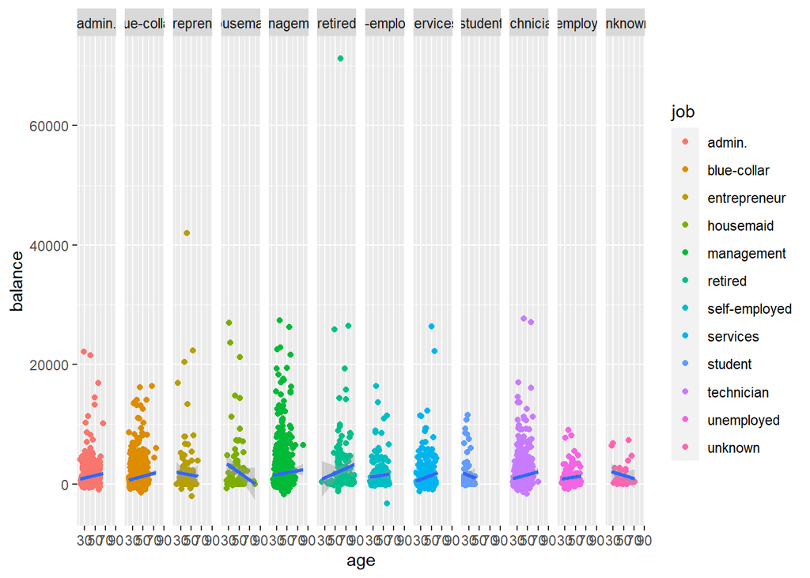

```r
g <- ggplot(bank, aes(age, balance))
g + geom_point(mapping = aes(color = job)) + geom_smooth(method = "lm") + facet_grid(. ~ job)
## `geom_smooth()` using formula 'y ~ x'
```

# Finding 2

It is very obvious that students have the smallest age, while the retired have the largest age. Some job categories have a relatively smaller age such as technician, services and entrepreneur. Some job categoreis have a relatively larter age such as management, and the unknown group.

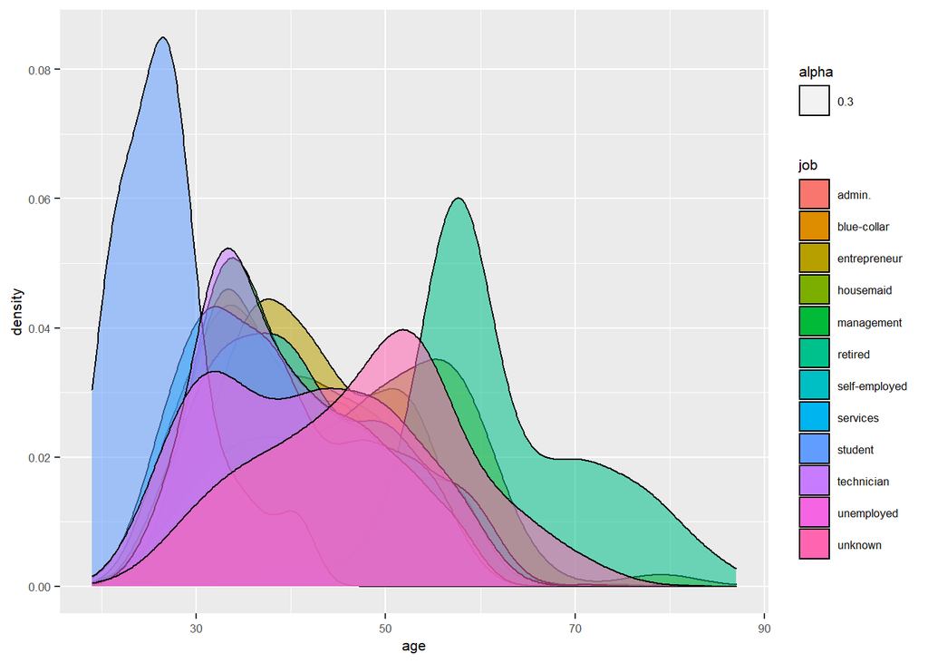

```r
ggplot(bank, aes(age, fill = job, alpha = 0.3)) + geom_density() +
theme(text = element_text(size=8))
```

# Finding 3

As the age increases, there is a larger proportion of the pulation with a primary / secondary education background.

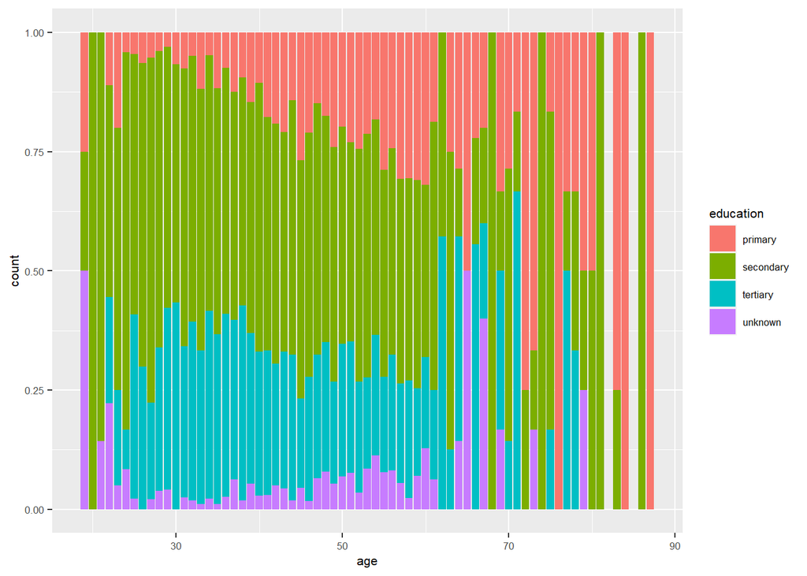

```r
ggplot(bank) + geom_bar(mapping = aes(x = age, fill = education),
position = "fill") +
theme(text = element_text(size=8))
```

# Finding 4

No matter the martial status, those without loan usually have a larger bank balance. Grouping in this way, the relationship between balance and age is not obvious as finding 1.

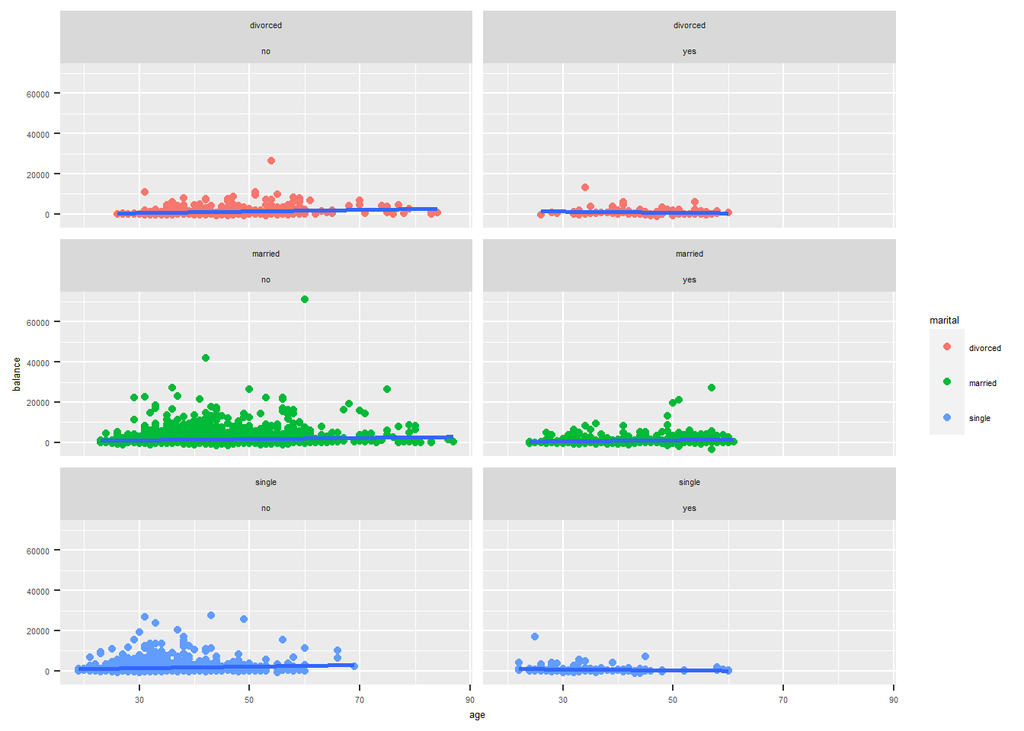

```r
ggplot(data = bank) +
geom_point(mapping = aes(x = age, y = balance, color = marital)) + geom_smooth(method = "lm", mapping = aes(x = age, y = balance)) +
facet_wrap(marital~loan , nrow = 3) +
theme(text = element_text(size=5))
## `geom_smooth()` using formula 'y ~ x'
```

# Finding 5

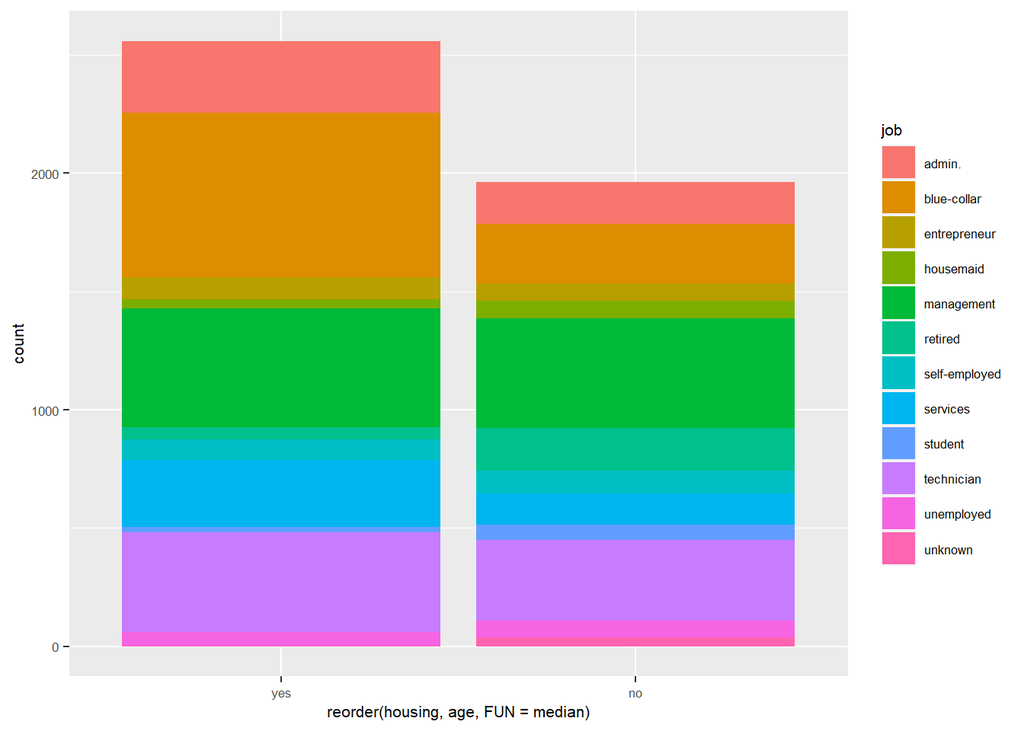

```r
ggplot(data = bank, mapping = aes(x = reorder(housing, age, FUN = median),
fill = job)) + geom_bar() +
scale_x_discrete(limit = rev(levels(factor(bank$housing)))) +
theme(text = element_text(size=8))
```

# Finding 6

Generally there is a negative relationship between duration and previous except the group without housing and with a negative y, but the correlation is not strong.

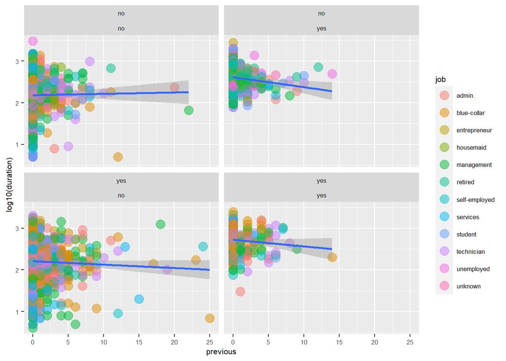

```r
ggplot(data = bank, mapping = aes(x = previous, y = log10(duration))) +
  geom_point(aes(color = job), size = 4, alpha = 1/2)  + geom_smooth(method = "lm") +
  facet_wrap(housing~y, nrow = 2) + theme(text = element_text(size=8))
## `geom_smooth()` using formula 'y ~ x'
```